# Statistique-python

# Test du Khi²

L'intérêt du test du Khi² est de mesurer l'indépendance entre deux variables qualitatives à partir du tableau de contingence.

On travaille sur le jeu de données Titanic 🧊⛴ disponible en [cliquant ici](https://github.com/asardell/statistique-python/tree/master/Dataset)

```python
# Lecture d'un fichier CSV et chargement des données dans un DataFrame pandas
# Le chemin du fichier est spécifié avec "../Dataset/Titanic.csv"
# index_col=0 indique que la première colonne du fichier CSV sera utilisée comme index du DataFrame
# Documentation pandas pour read_csv: https://pandas.pydata.org/pandas-docs/stable/reference/api/pandas.read_csv.html
df = pd.read_csv("../Dataset/Titanic.csv", index_col=0)

# Affichage des cinq premières lignes du DataFrame pour inspection
# Documentation pandas pour head: https://pandas.pydata.org/pandas-docs/stable/reference/api/pandas.DataFrame.head.html
df.head()
```

|  | Name | PClass | Age | Sex | Survived | SexCode |
| --- | --- | --- | --- | --- | --- | --- |
| 1 | Allen, Miss Elisabeth Walton | 1st | 29.00 | female | 1 | 1 |
| 2 | Allison, Miss Helen Loraine | 1st | 2.00 | female | 0 | 1 |
| 3 | Allison, Mr Hudson Joshua Creighton | 1st | 30.00 | male | 0 | 0 |
| 4 | Allison, Mrs Hudson JC (Bessie Waldo Daniels) | 1st | 25.00 | female | 0 | 1 |
| 5 | Allison, Master Hudson Trevor | 1st | 0.92 | male | 1 | 0 |

```python
# Création d'une table de contingence (crosstab) entre les colonnes 'Survived' et 'PClass' (passenger class) du DataFrame
# La table de contingence représente le nombre d'occurrences pour chaque combinaison de valeurs dans les deux colonnes
# Documentation pandas pour crosstab: https://pandas.pydata.org/pandas-docs/stable/reference/api/pandas.crosstab.html
df_count = pd.crosstab(df.Survived, df.PClass)

# Affichage de la table de contingence
df_count
```

| PClass Survived | 1st | 2nd | 3rd |
| --- | --- | --- | --- |
| 0 | 129 | 161 | 573 |
| 1 | 193 | 119 | 138 |

On pose les hypothèses de départ :

- H0 : Variables indépendantes si p-value > 5%
- H1 : Variables non indépendantes si p-value < 5%

### Survived vs PClass

```python
# Importation de la fonction chi2_contingency du module stats de scipy.stats
# chi2_contingency est utilisée pour effectuer un test du khi-deux sur une table de contingence
# Documentation scipy.stats pour chi2_contingency: https://docs.scipy.org/doc/scipy/reference/generated/scipy.stats.chi2_contingency.html
from scipy.stats import chi2_contingency

# Application de la fonction chi2_contingency à la table de contingence df_count
# La fonction renvoie plusieurs valeurs, dont le Khi2 observé, la valeur p, le degré de liberté et l'effectif théorique
Khi2_obs, p_value, ddl, effectif_theorique = chi2_contingency(df_count)
```

```python
p_value
```

```
3.852315502424536e-38
```

~H0 : Variables indépendantes si p-value > 5%~  
H1 : Variables non indépendantes si p-value < 5%

### Exemple sur des données fictives

```python
# Importation de la fonction chi2_contingency du module stats de scipy.stats
# chi2_contingency est utilisée pour effectuer un test du khi-deux sur une table de contingence
# Documentation scipy.stats pour chi2_contingency: https://docs.scipy.org/doc/scipy/reference/generated/scipy.stats.chi2_contingency.html
from scipy.stats import chi2_contingency

# Création d'une matrice numpy (obs) représentant une table de contingence
# La matrice a deux lignes (représentant deux catégories) et quatre colonnes (représentant quatre classes)
obs = np.array([[693, 886, 534, 153], [597, 696, 448, 95]])
# Affichage de la matrice de contingence (effectifs observés)
print("Matrice de contingence (effectifs observés):\n", obs)

# Application de la fonction chi2_contingency à la table de contingence représentée par la matrice 'obs'
# La fonction renvoie plusieurs valeurs, notamment le Khi2 observé, la valeur p, le degré de liberté et l'effectif théorique
# La fonction réalise un test statistique pour évaluer l'indépendance entre les deux variables catégoriques
chi2_result = chi2_contingency(obs)

# Affichage des résultats du test du khi-deux
print("\nRésultats du test du khi-deux:")
print("Khi2 observé:", chi2_result[0])
print("Valeur p:", chi2_result[1])
print("Degré de liberté:", chi2_result[2])
print("Effectif théorique:\n", chi2_result[3])
```

```
Matrice de contingence (effectifs observés):
 [[693 886 534 153]
 [597 696 448  95]]

Résultats du test du khi-deux:
Khi2 observé: 6.050399610728231
Valeur p: 0.1091837556828247
Degré de liberté: 3
Effectif théorique:
 [[712.61335934 873.91808874 542.47001463 136.9985373 ]
 [577.38664066 708.08191126 439.52998537 111.0014627 ]]
```

H0 : Variables indépendantes si p-value > 5%  
~H1 : Variables non indépendantes si p-value < 5%~  
Si on veut rejeter H0 et prendre H1, j'ai 10,9% de chance de me tromper

Le 10,9% correspond à la probabilité de rejeter à tord H0. Comment la calculer ?

Lecture dans la table du Chi2

```python
# Importation de la fonction chi2 du module stats de scipy.stats
# chi2.isf est utilisée pour calculer la fonction inverse de survie (inverse survival function) de la distribution du khi-deux
# Documentation scipy.stats pour chi2.isf: https://docs.scipy.org/doc/scipy/reference/generated/scipy.stats.chi2.html
from scipy.stats import chi2

# Définition des valeurs pour les degrés de liberté (J) et les quantiles (I)
# J représente les degrés de liberté de la distribution du khi-deux
# I représente les quantiles, c'est-à-dire les probabilités pour lesquelles calculer la fonction inverse de survie
J = np.arange(1, 5, 1)
I = np.arange(0.05, 0.15, 0.005)

# Création d'une matrice vide 'a' avec des dimensions basées sur la longueur de J et I
# La matrice sera remplie de valeurs NaN
a = np.empty((len(J), len(I)))
a[:] = np.nan

# Boucle imbriquée pour calculer chi2.isf pour chaque combinaison de J (degrés de liberté) et I (quantiles)
for i in range(0, len(I)):
    for j in range(0, len(J)):
        # Calcul de chi2.isf pour la combinaison actuelle de degrés de liberté (J[j]) et quantile (I[i])
        a[j, i] = chi2.isf(I[i], J[j])

# Création d'un DataFrame pandas (df_chi2) à partir de la matrice 'a' avec des colonnes nommées d'après les quantiles (I)
# et des index d'après les degrés de liberté (J)
df_chi2 = round(pd.DataFrame(a, columns=I, index=J), 5)

# Affichage du DataFrame df_chi2
df_chi2
```

|  | 0.050 | 0.055 | 0.060 | 0.065 | 0.070 | 0.075 | 0.080 | 0.085 | 0.090 | 0.095 | 0.100 | 0.105 | 0.110 | 0.115 | 0.120 | 0.125 | 0.130 | 0.135 | 0.140 | 0.145 |
| --- | --- | --- | --- | --- | --- | --- | --- | --- | --- | --- | --- | --- | --- | --- | --- | --- | --- | --- | --- | --- |
| 1 | 3.84146 | 3.68209 | 3.53738 | 3.40498 | 3.28302 | 3.17005 | 3.06490 | 2.96661 | 2.87437 | 2.78754 | 2.70554 | 2.62791 | 2.55422 | 2.48413 | 2.41732 | 2.35353 | 2.29250 | 2.23405 | 2.17796 | 2.12408 |
| 2 | 5.99146 | 5.80084 | 5.62682 | 5.46674 | 5.31852 | 5.18053 | 5.05146 | 4.93021 | 4.81589 | 4.70776 | 4.60517 | 4.50759 | 4.41455 | 4.32565 | 4.24053 | 4.15888 | 4.08044 | 4.00496 | 3.93223 | 3.86204 |
| 3 | 7.81473 | 7.60179 | 7.40688 | 7.22713 | 7.06031 | 6.90464 | 6.75869 | 6.62129 | 6.49146 | 6.36839 | 6.25139 | 6.13987 | 6.03333 | 5.93132 | 5.83346 | 5.73941 | 5.64888 | 5.56161 | 5.47734 | 5.39589 |
| 4 | 9.48773 | 9.25643 | 9.04437 | 8.84849 | 8.66643 | 8.49628 | 8.33653 | 8.18593 | 8.04344 | 7.90818 | 7.77944 | 7.65657 | 7.53904 | 7.42638 | 7.31816 | 7.21405 | 7.11371 | 7.01686 | 6.92325 | 6.83266 |

On cherche quelle est la probabilité critique pour laquelle **Khi2_obs** < Khi2_max de la table sur la ligne correspond à notre nombre de degré de liberté **ddl**

### 📢 Taille de l'échantillon

Les tests d'indépendance sont très sensibles à la taille des échantillons. Ici on divise par 100 pour avoir des effectifs faibles mais en conservant les répartitions.

```python
# Division des valeurs dans la matrice 'obs' par 100 pour obtenir des proportions plutôt que des effectifs
# Ceci est communément fait pour effectuer un test du khi-deux avec des proportions plutôt qu'avec des effectifs bruts
obs_normalized = obs / 100

# Application de la fonction chi2_contingency à la table de contingence normalisée (obs_normalized)
# La fonction renvoie plusieurs valeurs, notamment le Khi2 observé, la valeur p, le degré de liberté et l'effectif théorique
# Documentation scipy.stats pour chi2_contingency: https://docs.scipy.org/doc/scipy/reference/generated/scipy.stats.chi2_contingency.html
chi2_result_normalized = chi2_contingency(obs_normalized)
```

Ici on multiplie par 100 pour avoir des effectifs grands mais en conservant les répartitions.

```python
# Multiplication des valeurs dans la matrice 'obs' par 100 pour obtenir des effectifs artificiellement augmentés
# Ceci peut être fait pour explorer les variations dans le test du khi-deux avec des effectifs plus importants
obs_artificially_increased = obs * 100

# Application de la fonction chi2_contingency à la table de contingence artificiellement augmentée (obs_artificially_increased)
# La fonction renvoie plusieurs valeurs, notamment le Khi2 observé, la valeur p, le degré de liberté et l'effectif théorique
# Documentation scipy.stats pour chi2_contingency: https://docs.scipy.org/doc/scipy/reference/generated/scipy.stats.chi2_contingency.html
chi2_result_artificially_increased = chi2_contingency(obs_artificially_increased)

print(chi2_result_artificially_increased)
```

```
Chi2ContingencyResult(statistic=605.039961072823, pvalue=8.14310251740213e-131, dof=3, expected_freq=array([[71261.33593369, 87391.80887372, 54247.0014627 , 13699.85372989],
       [57738.66406631, 70808.19112628, 43952.9985373 , 11100.14627011]]))
```

~H0 : Variables indépendantes si p-value > 5%~  
H1 : Variables non indépendantes si p-value < 5%

# ANOVA

## Anova à 1 facteur

On effectue une analyse de variance pour mesurer l’indépendance entre une variable qualitative et une quantitative.

Exemple sur le dataset Hotdogs 🌭 disponible en [cliquant ici](https://github.com/asardell/statistique-python/tree/master/Dataset).

```python
# Lecture d'un fichier CSV et chargement des données dans un DataFrame pandas
# Le chemin du fichier est spécifié avec "../Dataset/Hotdogs.csv"
# sep=";" indique que le point-virgule est utilisé comme séparateur de colonnes dans le fichier CSV
# Documentation pandas pour read_csv: https://pandas.pydata.org/pandas-docs/stable/reference/api/pandas.read_csv.html
df = pd.read_csv("../Dataset/Hotdogs.csv", sep=",")

# Affichage des cinq premières lignes du DataFrame pour inspection
# Documentation pandas pour head: https://pandas.pydata.org/pandas-docs/stable/reference/api/pandas.DataFrame.head.html
df.head()
```

|  | Type;Calories;Sodium |
| --- | --- |
| 0 | Beef;186;495 |
| 1 | Beef;181;477 |
| 2 | Beef;176;425 |
| 3 | Beef;149;322 |
| 4 | Beef;184;482 |

```python
# Lecture d'un fichier CSV et chargement des données dans un DataFrame pandas
# Le chemin du fichier est spécifié avec "../Dataset/Hotdogs.csv"
# sep=";" indique que le point-virgule est utilisé comme séparateur de colonnes dans le fichier CSV
# Documentation pandas pour read_csv: https://pandas.pydata.org/pandas-docs/stable/reference/api/pandas.read_csv.html
df = pd.read_csv("../Dataset/Hotdogs.csv", sep=";")

# Affichage des cinq premières lignes du DataFrame pour inspection
# Documentation pandas pour head: https://pandas.pydata.org/pandas-docs/stable/reference/api/pandas.DataFrame.head.html
df.head()

# Sélection des valeurs uniques de la colonne 'Type' dans le DataFrame df
# La méthode unique() renvoie un tableau numpy contenant les valeurs distinctes de la colonne spécifiée
# Documentation pandas pour unique: https://pandas.pydata.org/pandas-docs/stable/reference/api/pandas.Series.unique.html
unique_types = df['Type'].unique()

# Affichage des valeurs uniques de la colonne 'Type'
print("Valeurs uniques de la colonne 'Type':", unique_types)
```

```
Valeurs uniques de la colonne 'Type': ['Beef' 'Meat' 'Poultry']
```

On va tester l’indépendance entre la variable qualitative Type et la variable quantitatives Calories.

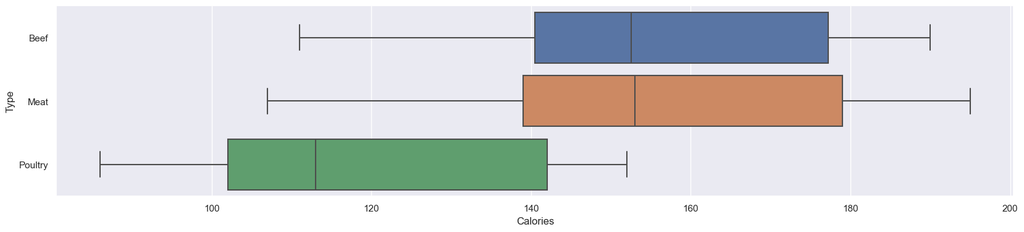

```python
# Création d'une figure et d'axes pour le tracé du graphique en boîte (boxplot)
# figsize=(20,4) spécifie la taille de la figure en pouces (largeur x hauteur)
# Documentation matplotlib.pyplot pour subplots: https://matplotlib.org/stable/api/_as_gen/matplotlib.pyplot.subplots.html
fig, ax = plt.subplots(figsize=(20, 4))

# Tracé d'un graphique en boîte (boxplot) en utilisant la bibliothèque seaborn (sns)
# 'x="Calories"' indique que la variable 'Calories' sera sur l'axe des x, 'y="Type"' indique que la variable 'Type' sera sur l'axe des y
# 'data=df' spécifie le DataFrame contenant les données
# Documentation seaborn pour boxplot: https://seaborn.pydata.org/generated/seaborn.boxplot.html
ax = sns.boxplot(x="Calories", y="Type", data=df)

# Affichage du graphique en boîte
plt.show()
```

Dans une ANOVA, on cherche à déterminer si les moyennes des groupes sont significativement différentes. On pose donc :

- H0 : Les moyennes de chaque groupe sont égales si p-value > 5%
- H1 : Les moyennes de chaque groupe ne sont pas toutes égales si p-value < 5%

```python
# Importation des modules statsmodels.api et ols (Ordinary Least Squares) de statsmodels.formula.api
# statsmodels est utilisé pour effectuer une analyse de la variance (ANOVA)
# Documentation statsmodels pour ols: https://www.statsmodels.org/stable/regression.html
import statsmodels.api as sm
from statsmodels.formula.api import ols

# Création d'un modèle de régression linéaire ordinaire (OLS) avec la formule 'Calories ~ Type'
# Cela signifie que nous modélisons la variable dépendante 'Calories' en fonction de la variable indépendante 'Type'
model = ols('Calories ~ Type', data=df).fit()

# Calcul de la table d'analyse de la variance (ANOVA)
# La fonction anova_lm() est utilisée pour effectuer une ANOVA sur le modèle
# 'typ=2' spécifie le type d'ANOVA à effectuer (type 2)
# Documentation statsmodels pour anova_lm: https://www.statsmodels.org/stable/anova.html
anova_table = sm.stats.anova_lm(model, typ=2)

# Affichage de la table d'analyse de la variance
anova_table
```

|  | sum_sq | df | F | PR(>F) |
| --- | --- | --- | --- | --- |
| Type | 17692.195098 | 2.0 | 16.073993 | 0.000004 |
| Residual | 28067.138235 | 51.0 | NaN | NaN |

~H0 : Les moyennes de chaque groupe sont égales si p-value > 5%~  
H1 : Les moyennes de chaque groupe ne sont pas toutes égales < 5%

Quand on dispose d’un petit échantillon, la pertinence de ce test repose sur la validation de plusieurs hypothèses :

- l’indépendance entre les échantillons de chaque groupe
- l’égalité des variances que l’on peut verifier avec un test de Bartlett.
- la normalité des résidus avec un test de Shapiro.

### L’égalité des variances

On parle aussi d’homoscédasticité (https://fr.wikipedia.org/wiki/Homosc%C3%A9dasticit%C3%A9). C’est une des 3 conditions de validité d’une ANOVA. On cherche à démontrer que les variances de chaque groupe sont égales. Dans un boxplot, l’amplitude des boîtes traduit graphiquement l’égalité des variances.

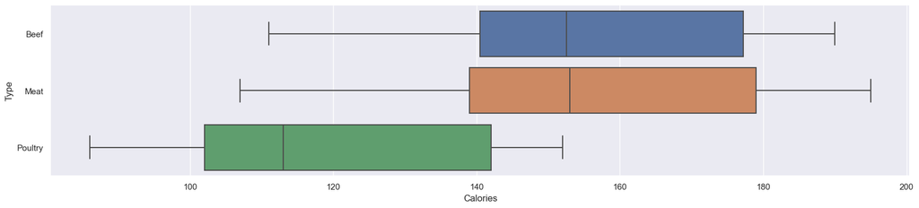

```python
# Création d'une figure et d'axes pour le tracé du graphique en boîte (boxplot)
# figsize=(20,4) spécifie la taille de la figure en pouces (largeur x hauteur)
# Documentation matplotlib.pyplot pour subplots: https://matplotlib.org/stable/api/_as_gen/matplotlib.pyplot.subplots.html
fig, ax = plt.subplots(figsize=(20, 4))

# Tracé d'un graphique en boîte (boxplot) en utilisant la bibliothèque seaborn (sns)
# 'x="Calories"' indique que la variable 'Calories' sera sur l'axe des x, 'y="Type"' indique que la variable 'Type' sera sur l'axe des y
# 'data=df' spécifie le DataFrame contenant les données
# Documentation seaborn pour boxplot: https://seaborn.pydata.org/generated/seaborn.boxplot.html
ax = sns.boxplot(x="Calories", y="Type", data=df)

# Affichage du graphique en boîte
plt.show()
```

```python
# Groupement du DataFrame df par la colonne 'Type' et calcul de la variance de la colonne 'Calories' pour chaque groupe
# La méthode groupby() divise le DataFrame en groupes en fonction des valeurs de la colonne spécifiée ('Type' dans ce cas)
# La méthode agg('var') calcule la variance pour chaque groupe
# Documentation pandas pour groupby: https://pandas.pydata.org/pandas-docs/stable/reference/api/pandas.DataFrame.groupby.html
# Documentation pandas pour agg: https://pandas.pydata.org/pandas-docs/stable/reference/api/pandas.DataFrame.agg.html
variance_by_type = df.groupby("Type")['Calories'].agg('var')

# Affichage des variances pour chaque groupe
print("Variances de la colonne 'Calories' pour chaque groupe 'Type':")
print(variance_by_type)
```

```
Variances de la colonne 'Calories' pour chaque groupe 'Type':
Type
Beef       512.660526
Meat       636.845588
Poultry    508.566176
Name: Calories, dtype: float64
```

Mais c’est le test de bartlett qui permet de tester si les variances sont significativement différentes ou non avec :

- H0 : Les variances de chaque groupe sont égales si p-value > 5%
- H1 : Les variances de chaque groupe ne sont pas toutes égales < 5%

```python
# Test de Bartlett pour l'égalité des variances entre trois groupes définis par la colonne 'Type' ('Beef', 'Meat', 'Poultry')
# La fonction bartlett() de scipy.stats est utilisée pour effectuer le test de Bartlett
# Elle teste l'hypothèse nulle que toutes les populations ont la même variance
# Documentation scipy.stats pour bartlett: https://docs.scipy.org/doc/scipy/reference/generated/scipy.stats.bartlett.html
bartlett_test_result = bartlett(df.Calories[df.Type == 'Beef'],
                                df.Calories[df.Type == 'Meat'],
                                df.Calories[df.Type == 'Poultry'])

# Affichage du résultat du test de Bartlett
print("Résultat du test de Bartlett:")
print("Statistic =", bartlett_test_result.statistic)
print("p-value =", bartlett_test_result.pvalue)
```

```
Résultat du test de Bartlett:
Statistic = 0.26731777374070764
p-value = 0.8748884496460629
```

- H0 : Les variances de chaque groupe sont égales si p-value > 5%
- ~H1 : Les variances de chaque groupe ne sont pas toutes égales < 5%~

Les variances de chaque groupe sont égales. La deuxième condition pour effectuer une anova est validée.

### Normalité des résidus

C’est une des 3 conditions de validité d’une ANOVA. L’objectif est de s’assurer que les résidus suivent une loi normale afin de ne pas affirmer qu’il existe une différence de moyenne entre les groupes qui serait causée par le hasard.

On utilise le test de Shapiro-Wilk pour tester la normalité des résidus où :

- H0 : Les résidus suivent une loi normale si p-value > 5%
- H1 : Les résidus ne suivent pas une loi normale si p-value < 5%

```python
# Importation de la fonction shapiro du module scipy.stats
# La fonction shapiro est utilisée pour effectuer le test de normalité de Shapiro-Wilk sur les résidus du modèle de régression
# Documentation scipy.stats pour shapiro: https://docs.scipy.org/doc/scipy/reference/generated/scipy.stats.shapiro.html
from scipy.stats import shapiro

# Ajustement du modèle de régression linéaire ordinaire (OLS) avec la formule 'Calories ~ Type'
model = ols('Calories ~ Type', data=df).fit()

# Application du test de normalité de Shapiro-Wilk sur les résidus du modèle
# La fonction shapiro() renvoie la statistique de test (W) et la valeur p
shapiro_test_result = shapiro(model.resid)

# Affichage du résultat du test de normalité de Shapiro-Wilk
print("Résultat du test de normalité de Shapiro-Wilk:")
print("Statistique de test (W) =", shapiro_test_result.statistic)
print("p-value =", shapiro_test_result.pvalue)
```

```
Résultat du test de normalité de Shapiro-Wilk:
Statistique de test (W) = 0.9419925808906555
p-value = 0.01129539217799902
```

- ~H0 : Les résidus suivent une loi normale si p-value > 5%~
- H1 : Les résidus ne suivent pas une loi normale si p-value < 5%

Néanmoins, les conclusions dépendent également tu risques qu'on souhaite. Si on veut 1% de chance de se tromper, alors on ne rejette pas H0 car la p-value > 1%

### Cas de variances égales entre chaque groupe

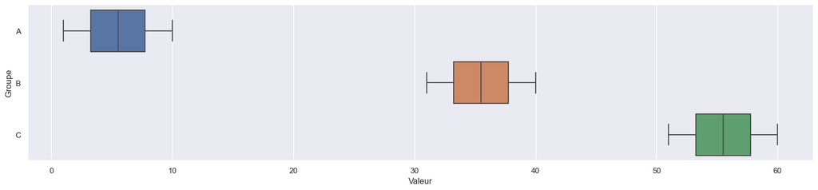

```python
# Création de trois séries pandas contenant des valeurs linéaires de 1 à 10, 31 à 40, et 51 à 60 respectivement
A = pd.Series(np.linspace(1, 10, 9), name='A')
B = pd.Series(np.linspace(31, 40, 9), name='B')
C = pd.Series(np.linspace(51, 60, 9), name='C')

# Création d'une série pandas contenant les labels de groupe ('A', 'B', 'C') répétés 9 fois chacun
Groupe = pd.Series(['A', 'B', 'C']).repeat(9).to_list()

# Création d'un DataFrame résultant de la concaténation des séries A, B, C et Groupe
# Chaque série A, B, C correspond à une colonne et la série Groupe est ajoutée comme colonne 'Groupe'
frame = {'Groupe': Groupe, 'Valeur': pd.concat([A, B, C])}
result = pd.DataFrame(frame)

# Création d'un graphique en boîte (boxplot) en utilisant seaborn pour visualiser la distribution des valeurs par groupe
# 'x="Valeur"' indique que la variable 'Valeur' sera sur l'axe des x, 'y="Groupe"' indique que la variable 'Groupe' sera sur l'axe des y
# Documentation seaborn pour boxplot: https://seaborn.pydata.org/generated/seaborn.boxplot.html
plt.subplots(figsize=(20, 4))
ax = sns.boxplot(x="Valeur", y="Groupe", data=result)
```

On s'interesse au variance de chaque groupe

```python
# Groupement du DataFrame result par la colonne 'Groupe' et calcul de la variance de la colonne 'Valeur' pour chaque groupe
# La méthode groupby() divise le DataFrame en groupes en fonction des valeurs de la colonne spécifiée ('Groupe' dans ce cas)
# La méthode agg('var') calcule la variance pour chaque groupe
# Documentation pandas pour groupby: https://pandas.pydata.org/pandas-docs/stable/reference/api/pandas.DataFrame.groupby.html
# Documentation pandas pour agg: https://pandas.pydata.org/pandas-docs/stable/reference/api/pandas.DataFrame.agg.html
variance_by_groupe = result.groupby("Groupe")['Valeur'].agg('var')

# Affichage des variances pour chaque groupe
print("Variances de la colonne 'Valeur' pour chaque groupe 'Groupe':")
print(variance_by_groupe)
```

```
Variances de la colonne 'Valeur' pour chaque groupe 'Groupe':
Groupe
A    9.492188
B    9.492188
C    9.492188
Name: Valeur, dtype: float64
```

Le test de bartlett permet de tester si les variances sont significativement différentes ou non

```python
# Importation de la fonction bartlett du module scipy.stats
# La fonction bartlett est utilisée pour effectuer le test de Bartlett pour l'égalité des variances entre plusieurs groupes
# Documentation scipy.stats pour bartlett: https://docs.scipy.org/doc/scipy/reference/generated/scipy.stats.bartlett.html
from scipy.stats import bartlett

# Application du test de Bartlett pour évaluer l'égalité des variances entre les groupes A, B et C
bartlett_test_result = bartlett(A, B, C)

# Affichage du résultat du test de Bartlett
print("Résultat du test de Bartlett:")
print("Statistique de test =", bartlett_test_result.statistic)
print("p-value =", bartlett_test_result.pvalue)
```

```
Résultat du test de Bartlett:
Statistique de test = 0.0
p-value = 1.0
```

H0 : Les variances de chaque groupe sont égales si p-value > 5%  
~H1 : Les variances de chaque groupe ne sont pas toutes égales < 5%~  
On peut donc faire une ANOVA

```python
# Importation du module statsmodels.api pour les modèles statistiques
import statsmodels.api as sm

# Importation du module statsmodels.formula.api pour la spécification des modèles à l'aide de formules
from statsmodels.formula.api import ols
```

A travers l'analyse de la variance on cherche à déterminer si :  
H0 : Les moyennes de chaque groupe sont égales si p-value > 5%  
H1 : Les moyennes de chaque groupe ne sont pas toutes égales < 5%

```python
# Spécification et ajustement du modèle de régression linéaire ordinaire (OLS) avec la formule 'Valeur ~ Groupe'
# La fonction ols() permet de spécifier un modèle de régression linéaire à partir d'une formule
# La formule 'Valeur ~ Groupe' indique que 'Valeur' est la variable dépendante et 'Groupe' est la variable indépendante
# La méthode fit() ajuste réellement le modèle aux données du DataFrame result
model = ols('Valeur ~ Groupe', data=result).fit()

# Calcul de la table d'analyse de la variance (ANOVA) à l'aide de statsmodels
# La méthode anova_lm de statsmodels.stats est utilisée pour effectuer l'ANOVA
# 'typ=2' spécifie le type d'ANOVA à effectuer, dans ce cas, ANOVA Type II
# Documentation statsmodels pour anova_lm: https://www.statsmodels.org/stable/generated/statsmodels.stats.anova.anova_lm.html
# L'ANOVA évalue la significativité globale du modèle et la contribution de chaque variable indépendante
anova_table = sm.stats.anova_lm(model, typ=2)

# Affichage de la table d'analyse de la variance (ANOVA)
# La table ANOVA fournit des informations telles que la somme des carrés, les degrés de liberté, les carrés moyens,
# et les valeurs F associées à chaque terme du modèle
# Cela permet d'évaluer la significativité des variables indépendantes dans le modèle
print(anova_table)
```

```
              sum_sq    df           F        PR(>F)
Groupe    11400.0000   2.0  600.493827  3.198559e-21
Residual    227.8125  24.0         NaN           NaN
```

~H0 : Les moyennes de chaque groupe sont égales si p-value > 5%~  
H1 : Les moyennes de chaque groupe ne sont pas toutes égales < 5%

### Cas de variances inégales entre chaque groupe

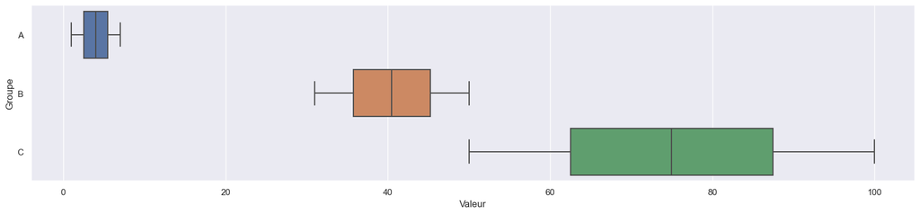

```python
# Création de trois séries de données (A, B, C) avec des valeurs linéaires
A = pd.Series(np.linspace(1, 7, 9), name='A')
B = pd.Series(np.linspace(31, 50, 9), name='B')
C = pd.Series(np.linspace(50, 100, 9), name='C')

# Création d'une série de catégories (Groupe) en répétant les valeurs 'A', 'B', 'C' neuf fois chacune
Groupe = pd.Series(['A', 'B', 'C']).repeat(9).to_list()

# Construction d'un DataFrame 'result' à partir des séries A, B, C et Groupe
# La colonne 'Groupe' contient les catégories et la colonne 'Valeur' contient les données concaténées
frame = {'Groupe': Groupe, 'Valeur': pd.concat([A, B, C])}
result = pd.DataFrame(frame)

# Création d'une boîte à moustaches (boxplot) pour visualiser la distribution des valeurs par groupe
# La fonction plt.subplots() permet de spécifier la taille de la figure (20 de large, 4 de haut)
plt.subplots(figsize=(20, 4))
ax = sns.boxplot(x="Valeur", y="Groupe", data=result)
```

```python
# Test de l'égalité des variances avec le test de Bartlett
# La fonction bartlett() du module scipy.stats est utilisée pour comparer les variances de plusieurs échantillons
# Elle teste l'hypothèse nulle que toutes les échantillons ont la même variance
# Documentation pour bartlett: https://docs.scipy.org/doc/scipy/reference/generated/scipy.stats.bartlett.html
bartlett_test_result = bartlett(A, B, C)
print(bartlett_test_result)
```

```
BartlettResult(statistic=25.177363348990262, pvalue=3.410397602490597e-06)
```

~H0 : Les variances de chaque groupe sont égales si p-value > 5%~  
H1 : Les variances de chaque groupe ne sont pas toutes égales < 5%  
Il n'est donc pas conseillé de réaliser une ANOVA car les résultats ne seraient pas fiables.

## Anova à 2 facteurs

Même principe que l'Anova à un facteur sauf qu'on ajoute un autre facteur. L'idée est de tester l'indépendance de ces facteurs sur une variable quantitative continue

On utilise le dataset ToothGrowth disponible en [cliquant ici](https://github.com/asardell/statistique-python/tree/master/Dataset). On étudie la longueur des odontoblastes (cellules responsables de la croissance dentaire) chez 60 cobayes. Chaque animal a reçu l'une des trois doses de vitamine C (0,5, 1 et 2 mg / jour) par l'une des deux méthodes d'administration, du jus d'orange ou de l'acide ascorbique (une forme de vitamine C et codée VC) :

- len : lLongueur de la dent
- supp : supplément (VC ou OJ).
- dose : dose en milligrammes / jour

```python
# Lecture d'un fichier CSV contenant des données sur la croissance des dents
# Le chemin du fichier est spécifié avec "../Dataset/ToothGrowth.csv"
df = pd.read_csv("../Dataset/ToothGrowth.csv")

# Affichage des trois premières lignes du DataFrame pour inspection
# Documentation pandas pour read_csv: https://pandas.pydata.org/pandas-docs/stable/reference/api/pandas.read_csv.html
df.head(3)
```

|  | len | supp | dose |
| --- | --- | --- | --- |
| 0 | 4.2 | VC | 0.5 |
| 1 | 11.5 | VC | 0.5 |
| 2 | 7.3 | VC | 0.5 |

#### On étudie la variable supp

```python
# Sélection des valeurs uniques de la colonne 'supp' dans le DataFrame df
# La méthode unique() renvoie un tableau numpy contenant les valeurs distinctes de la colonne spécifiée
# Documentation pandas pour unique: https://pandas.pydata.org/pandas-docs/stable/reference/api/pandas.Series.unique.html
supp_unique_values = df.supp.unique()
print(supp_unique_values)
```

```
['VC' 'OJ']
```

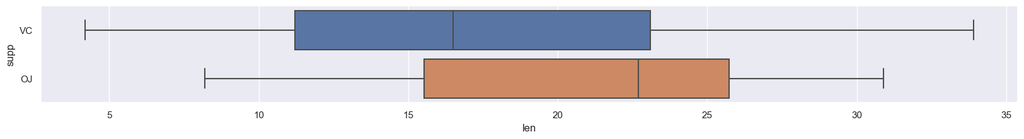

```python
# Création d'une boîte à moustaches (boxplot) pour visualiser la distribution de la colonne 'len' par catégorie 'supp'
# La fonction plt.subplots() permet de spécifier la taille de la figure (20 de large, 2 de haut)
plt.subplots(figsize=(20, 2))

# Utilisation de Seaborn pour créer le boxplot
# La fonction sns.boxplot() prend en paramètres les données du DataFrame df, avec 'len' sur l'axe des x et 'supp' sur l'axe des y
ax = sns.boxplot(x="len", y="supp", data=df)
```

```python
# Test de Bartlett pour comparer les variances des échantillons 'VC' et 'OJ' de la colonne 'len' dans le DataFrame df
# La fonction bartlett() du module scipy.stats est utilisée pour effectuer ce test
# Elle teste l'hypothèse nulle que les échantillons ont des variances égales
# Documentation pour bartlett: https://docs.scipy.org/doc/scipy/reference/generated/scipy.stats.bartlett.html
bartlett_test_result = bartlett(df.len[df.supp == 'VC'], df.len[df.supp == 'OJ'])
print(bartlett_test_result)
```

```
BartlettResult(statistic=1.421682114943345, pvalue=0.23312673355220734)
```

H0 : Les variances de chaque groupe sont égales si p-value > 5%  
~H1 : Les variances de chaque groupe ne sont pas toutes égales < 5%~

#### On étudie la variable dose

```python
# Sélection des valeurs uniques de la colonne 'dose' dans le DataFrame df
# La méthode unique() renvoie un tableau numpy contenant les valeurs distinctes de la colonne spécifiée
# Documentation pandas pour unique: https://pandas.pydata.org/pandas-docs/stable/reference/api/pandas.Series.unique.html
dose_unique_values = df.dose.unique()
print(dose_unique_values)
```

```
[0.5 1.  2. ]
```

```python
# Conversion de la colonne 'dose' en type de données catégorielles (category) dans le DataFrame df
# La méthode astype() permet de changer le type de données d'une colonne, ici de 'object' à 'category'
# Cela est utile pour représenter des variables catégorielles de manière plus efficace
# Documentation pandas pour astype: https://pandas.pydata.org/pandas-docs/stable/reference/api/pandas.DataFrame.astype.html
df.dose = df.dose.astype('category')
```

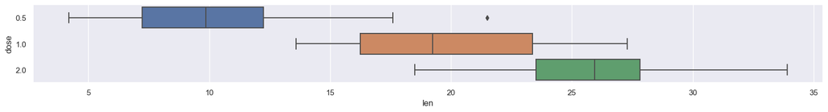

```python
# Création d'une boîte à moustaches (boxplot) pour visualiser la distribution de la colonne 'len' par catégorie 'dose'
# La fonction plt.subplots() permet de spécifier la taille de la figure (20 de large, 2 de haut)
plt.subplots(figsize=(20, 2))

# Utilisation de Seaborn pour créer le boxplot
# La fonction sns.boxplot() prend en paramètres les données du DataFrame df, avec 'len' sur l'axe des x et 'dose' sur l'axe des y
ax = sns.boxplot(x="len", y="dose", data=df)
```

```python
bartlett(df.len[df.dose == "0.5"],
        df.len[df.dose == "1.0"],
        df.len[df.dose == "2.0"])
```

```
BartlettResult(statistic=nan, pvalue=nan)
```

H0 : Les moyennes de chaque groupe sont égales si p-value > 5%  
H1 : Les moyennes de chaque groupe ne sont pas toutes égales < 5%

```python
model = ols('len ~ supp + dose', data=df).fit()
```

```python
anova_table = sm.stats.anova_lm(model, typ=2)
anova_table
```

|  | sum_sq | df | F | PR(>F) |
| --- | --- | --- | --- | --- |
| supp | 205.350000 | 1.0 | 14.016638 | 4.292793e-04 |
| dose | 2426.434333 | 2.0 | 82.810935 | 1.871163e-17 |
| Residual | 820.425000 | 56.0 | NaN | NaN |

📢 Le principe de l'Anova à plusieurs facteurs c'est justement de pouvoir observer les intéractions entre les variables

```python
model = ols('len ~ supp + dose + supp:dose', data=df).fit()

anova_table = sm.stats.anova_lm(model, typ=2)
anova_table
```

|  | sum_sq | df | F | PR(>F) |
| --- | --- | --- | --- | --- |
| supp | 205.350000 | 1.0 | 15.571979 | 2.311828e-04 |
| dose | 2426.434333 | 2.0 | 91.999965 | 4.046291e-18 |
| supp:dose | 108.319000 | 2.0 | 4.106991 | 2.186027e-02 |
| Residual | 712.106000 | 54.0 | NaN | NaN |

📢 On voit donc qu'il existe une intéraction entre les deux variables. Pour mesurer quelles associations sont significativement différentes des autres, on peut utilise un test de Tukey qui consiste à faire des tests de comparaison de moyenne sur deux échantillon avec toutes les combinaisons d'association

Pour cela, on crée une colonne avec les combinaisons des deux facteurs.

```python
df['combinaison'] = df['supp'] + '-' + df['dose'].astype('str')
df.head(3)
```

|  | len | supp | dose | combinaison |
| --- | --- | --- | --- | --- |
| 0 | 4.2 | VC | 0.5 | VC-0.5 |
| 1 | 11.5 | VC | 0.5 | VC-0.5 |
| 2 | 7.3 | VC | 0.5 | VC-0.5 |

```python
import statsmodels.stats.multicomp as multi
Results = multi.MultiComparison(df['len'], df['combinaison'])
Results = Results.tukeyhsd()
print(Results)
```

```
 Multiple Comparison of Means - Tukey HSD, FWER=0.05
======================================================
group1 group2 meandiff p-adj   lower    upper   reject
------------------------------------------------------
OJ-0.5 OJ-1.0     9.47    0.0   4.6719  14.2681   True
OJ-0.5 OJ-2.0    12.83    0.0   8.0319  17.6281   True
OJ-0.5 VC-0.5    -5.25 0.0243 -10.0481  -0.4519   True
OJ-0.5 VC-1.0     3.54  0.264  -1.2581   8.3381  False
OJ-0.5 VC-2.0    12.91    0.0   8.1119  17.7081   True
OJ-1.0 OJ-2.0     3.36 0.3187  -1.4381   8.1581  False
OJ-1.0 VC-0.5   -14.72    0.0 -19.5181  -9.9219   True
OJ-1.0 VC-1.0    -5.93 0.0074 -10.7281  -1.1319   True
OJ-1.0 VC-2.0     3.44 0.2936  -1.3581   8.2381  False
OJ-2.0 VC-0.5   -18.08    0.0 -22.8781 -13.2819   True
OJ-2.0 VC-1.0    -9.29    0.0 -14.0881  -4.4919   True
OJ-2.0 VC-2.0     0.08    1.0  -4.7181   4.8781  False
VC-0.5 VC-1.0     8.79    0.0   3.9919  13.5881   True
VC-0.5 VC-2.0    18.16    0.0  13.3619  22.9581   True
VC-1.0 VC-2.0     9.37    0.0   4.5719  14.1681   True
------------------------------------------------------
```